# FF_Pracice_act_9.1

## The Data

At this link, you will find a dataset containing information about heart disease patients: https://www.dropbox.com/scl/fi/0vrpdnq5asmeulc4gd50y/ha_1.csv?rlkey=ciisalceotl77ffqhqe3kujzv&dl=1

A description of the original dataset can be found here: https://archive.ics.uci.edu/dataset/45/heart+disease (However, this dataset has been cleaned and reduced, and the people have been given fictious names.)

## 1. Logistic Regression

Fit a Logistic Regression using only `age` and `chol` (cholesterol) as predictors.

For a 55 year old, how high would their cholesterol need to be for the doctors to predict heart disease is present?

How high for the doctors to estimate a 90% chance that heart disease is present?

```python
import pandas as pd
import numpy as np
from sklearn.pipeline import Pipeline
from sklearn.neighbors import KNeighborsClassifier
from sklearn.tree import DecisionTreeClassifier
from sklearn.linear_model import LogisticRegression
from sklearn.compose import make_column_selector, ColumnTransformer
from sklearn.preprocessing import StandardScaler, OneHotEncoder, PolynomialFeatures
from sklearn.model_selection import train_test_split, cross_val_score, GridSearchCV
from sklearn.metrics import roc_curve, auc, confusion_matrix, accuracy_score, recall_score, precision_score, cohen_kappa_score
from plotnine import *
from sklearn.discriminant_analysis import LinearDiscriminantAnalysis as LDA
from sklearn.svm import SVC
```

```python
ha = pd.read_csv("https://www.dropbox.com/scl/fi/0vrpdnq5asmeulc4gd50y/ha_1.csv?rlkey=ciisalceotl77ffqhqe3kujzv&dl=1")
```

```python
X = ha[['age','chol']]
y = ha['diagnosis']

model_pipeline = Pipeline([
        ("model", LogisticRegression())
    ])

fit = model_pipeline.fit(X,y)

model = model_pipeline.named_steps['model']


LRcoefficients = model.coef_[0]
LRintercept = model.intercept_[0]

coef_df = pd.DataFrame({
    'Feature': X.columns.tolist() + ['Intercept'],
    'Coefficient': LRcoefficients.tolist() + [LRintercept]
})

print(coef_df)
```

```
     Feature  Coefficient
0        age     0.046863
1       chol     0.001801
2  Intercept    -3.240112
```

```python
z = np.log(.9/(1-.9))

(z - (.04686 * 55) - (-3.24))/.001801
```

```
1587.9647847508159
```

```python
(-(.04686 * 55) - (-3.24))/.001801
```

```
367.96224319822323
```

## 2. Linear Discriminant Analysis

Fit an LDA model using only `age` and `chol` (cholesterol) as predictors.

For a 55 year old, how high would their cholesterol need to be for the doctors to predict heart disease is present?

it would need to be above 368.18

```python
X = ha[['age','chol']]
y = ha['diagnosis']

model_pipeline = Pipeline([
        ("model", LDA())
    ])

fit = model_pipeline.fit(X,y)

model = model_pipeline.named_steps['model']

LDAcoefficients = model.coef_[0]
LDAintercept = model.intercept_[0]

coef_df = pd.DataFrame({
    'Feature': X.columns.tolist() + ['Intercept'],
    'Coefficient': LDAcoefficients.tolist() + [LDAintercept]
})

print(coef_df)
```

```
     Feature  Coefficient
0        age     0.046557
1       chol     0.001790
2  Intercept    -3.219678
```

```python
(-(.046557 * 55) - (-3.219678))/.00179
```

```
368.18044692737436
```

## 3. Support Vector Classifier

Fit an SVC model using only `age` and `chol` as predictors. Don’t forget to tune the regularization parameter.

For a 55 year old, how high would their cholesterol need to be for the doctors to predict heart disease is present?

it would need to be above 312.66

```python
X = ha[['age','chol']]
y = ha['diagnosis']

model_pipeline = Pipeline([
        ("model", SVC(kernel = 'linear'))
    ])

degree = {'model__C': np.array([.001,.01,.05,.1, .2,.5])}

gscv = GridSearchCV(model_pipeline, degree, cv = 5, scoring='accuracy')
tuning = gscv.fit(X, y)

best_model = tuning.best_estimator_

fit = best_model.fit(X,y)

model = best_model.named_steps['model']


SVCcoefficients = model.coef_[0]
SVCintercept = model.intercept_[0]

coef_df = pd.DataFrame({
    'Feature': X.columns.tolist() + ['Intercept'],
    'Coefficient': SVCcoefficients.tolist() + [SVCintercept]
})

print(coef_df)
```

```
     Feature  Coefficient
0        age     0.064398
1       chol     0.003661
2  Intercept    -4.686550
```

```python
(-(.064398 * 55) - (-4.68655))/.003661
```

```
312.66320677410556
```

## 4. Comparing Decision Boundaries

Make a scatterplot of `age` and `chol`, coloring the points by their true disease outcome. Add a line to the plot representing the **linear separator** (aka **decision boundary**) for each of the three models above.

```python
SVC_age = SVCcoefficients[0]
SVC_chol = SVCcoefficients[1]
SVC_inter = SVCintercept

LDA_age = LDAcoefficients[0]
LDA_chol = LDAcoefficients[1]
LDA_inter = LDAintercept

LR_age = LRcoefficients[0]
LR_chol = LRcoefficients[1]
LR_inter = LRintercept

SVCslope = -SVC_age/SVC_chol
LDAslope = -LDA_age/LDA_chol
LRslope = -LR_age/LR_chol

SVCinter = -SVC_inter/SVC_chol
LDAinter = -LDA_inter/LDA_chol
LRinter = -LR_inter/LR_chol
```

0 = w1x1 +w2x2 + c  
-w2x2 = w1x1 + c  
x2 = - w1/w2 x1 - c/w2

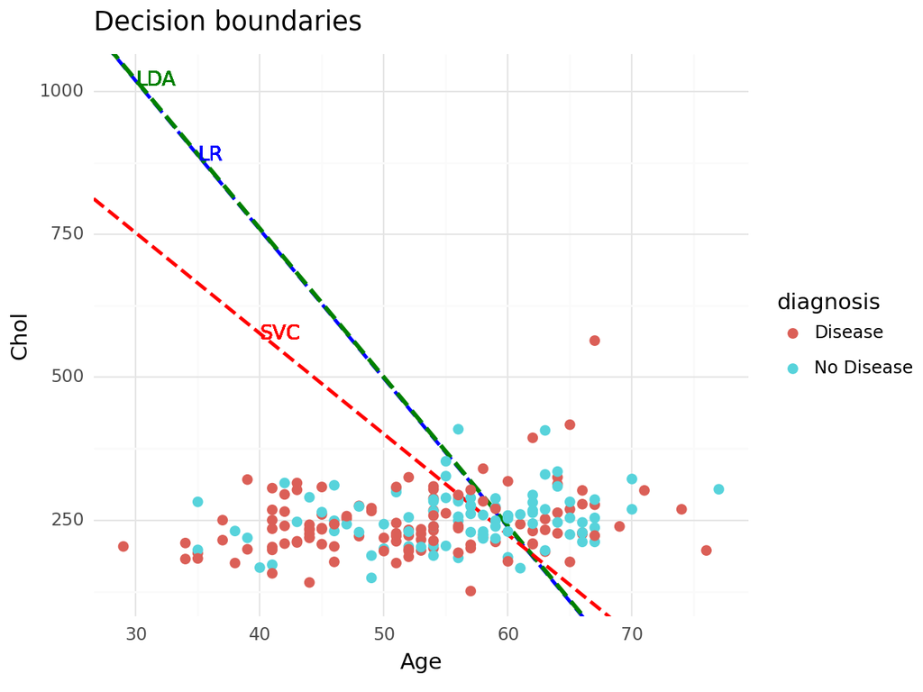

```
<Figure Size: (640 x 480)>
```

```python
plot = (ggplot(ha) +
        geom_abline(aes(slope=LRslope, intercept=LRinter), color='blue', linetype='dashed', size=1) +
        geom_abline(aes(slope=LDAslope, intercept=LDAinter), color='green', linetype='dashed', size=1.2) +
        geom_abline(aes(slope=SVCslope, intercept=SVCinter), color='red', linetype='dashed', size=1) +
        geom_point(aes(x='age', y='chol', color='diagnosis'), size=2) +
        labs(title='Decision boundaries', x='Age', y='Chol') +
        theme_minimal()
        )

plot += geom_text(aes(x=30, y=LDAslope * 30 + LDAinter), label="LDA", color="green", size=10, ha='left')
plot += geom_text(aes(x=35, y=LRslope * 35 + LRinter), label="LR", color="blue", size=10, ha='left')
plot += geom_text(aes(x=40, y=SVCslope * 40 + SVCinter), label="SVC", color="red", size=10, ha='left')

plot
```